# R_report_Benjamin_E4294137

Define a method for this class to calculate and display the gene’s average expression per base (expression/length).

```r
# Define a generic function for average expression per base
setGeneric("average_Expression_Per_Base", function(object) standardGeneric("average_Expression_Per_Base"))
```

```
## [1] "average_Expression_Per_Base"
```

```r
# Define the method for objects of class 'Gene'
setMethod(
  "average_Expression_Per_Base",
  "Gene",
  function(object) {
    # Calculate the average expression per base
    avg_expr <- object@expression / object@length

    # Display a message showing the result
    message("The average expression per base for ", object@gene_name, ": ", round(avg_expr, 6))

    # Return the calculated value
    return(avg_expr)
  }
)

# Test the method on the 'brca1_gene' object
average_Expression_Per_Base(abl1_gene)
```

```
## The average expression per base for ABL1: 0.006571
```

```
## [1] 0.006570513
```

**QUESTION 4A**

The Fibonacci sequence is often used in computational simulations. Modify the Fibonacci series to model a simplified population growth of bacteria.Assume the sequence starts with 2 bacteria, with the next generation doubling the sum of the two previous generations: 2, 4, 12, 32, … Write a function that: a) Generates the first 20 terms of this sequence.

```r
# Function to generate the first 'n' terms of a modified Fibonacci sequence
# This models simplified bacterial growth:
# Each generation is double the sum of the previous two generations.

bacterial_growth_sequence <- function(total_generations = 20) {

  # Ensure the input is a positive integer
  if (total_generations <= 0 || total_generations != as.integer(total_generations)) {
    stop("Input must be a positive whole number.")
  }

  # Initialise a numeric vector to store population values for each generation
  bacterial_growth <- numeric(total_generations)

  # Set the population values for the first two generations
  bacterial_growth[1] <- 2   # Generation 1
  bacterial_growth[2] <- 4   # Generation 2

  # Compute population for subsequent generations using the recurrence relation
  for (gen in 3:total_generations) {
    bacterial_growth[gen] <- 2 * (bacterial_growth[gen - 1] + bacterial_growth[gen - 2])
  }

  # Return the complete population sequence
  return(bacterial_growth)
}

# Generate and display the first 20 terms of the bacterial population sequence
bacterial_sequence_20 <- bacterial_growth_sequence(20)

cat("The first 20 terms of the bacterial growth sequence are:\n")
```

```
## The first 20 terms of the bacterial growth sequence are:
```

```r
print(bacterial_sequence_20)
```

```
##  [1]         2         4        12        32        88       240       656
##  [8]      1792      4896     13376     36544     99840    272768    745216
## [15]   2035968   5562368  15196672  41518080 113429504 309895168
```

**QUESTION 4B**

```r
# Function to count how many values in a sequence are divisible by 4
count_divisible_by_4 <- function(sequence) {
  # Use modulo operation to identify divisible terms and sum the logical values
  divisible_count <- sum(sequence %% 4 == 0)
  return(divisible_count)
}

# Apply the function to the bacterial sequence
num_divisible_by_4 <- count_divisible_by_4(bacterial_sequence_20)

# Display the result
cat("The number of terms divisible by 4 is:", num_divisible_by_4, "\n")
```

```
## The number of terms divisible by 4 is: 19
```

**Question 4c** Calculates the total number of bacteria in the 20th generation.

```r
# Retrieve the population size for the 20th generation ( 20th term of the sequence)
bacteria_20th_generation <- bacterial_sequence_20[20]

# Display the population size
cat("The total number of bacteria in the 20th generation is:", bacteria_20th_generation, "\n")
```

```
## The total number of bacteria in the 20th generation is: 309895168
```

**QUESTION 5A**

Q5 (40 marks) Tables GSE9476_series_matrix.txt (tab-delimited) and GSE9476_meta_info.txt are the microarray gene expression dataset and sample information table about patients with Acute Myeloid Leukemia (AML) and normal subjects as Controls. The expression data have been log2 transformed. Please complete the following tasks.

1. How many patients are with AML and how many are the control cases? How many genes(probesets) are we studying

```r
library(ggplot2)
library(dplyr)
library(readr)
library(tibble)
library(tidyr)
library(limma)
library(VennDiagram)
library(grid)


#load and inspect the metadata

# The metadata file contains information about the disease status of each sample

sample_metadata <- read.table("C:/Users/44798/Downloads/Archive-datasets (1) (1)/GSE9476_meta_info.txt", header = TRUE, sep = "\t", fill = TRUE, stringsAsFactors = FALSE)

# load and inspect the expression_matrix data set

# Skipping the first 83 lines to bypass header comments in the file

raw_expression_data <- read.table("C:/Users/44798/Downloads/Archive-datasets (1) (1)/GSE9476_series_matrix.txt", header = TRUE, sep = "\t", skip = 83, fill = TRUE, stringsAsFactors = FALSE)

# Extract gene/probe identifiers from the first column
gene_ids <- raw_expression_data[, 1]

# Extract the expression values and remove the first column
expression_matrix <- raw_expression_data[, -1]

# Set gene IDs as row names for easier downstream analysis
rownames(expression_matrix) <- gene_ids

# Check the number of genes (rows) and samples (columns)
num_genes <- nrow(expression_matrix)
num_samples <- ncol(expression_matrix)

# Count the number of AML patients and control subjects using the sample_metadata
num_aml_patients <- sum(sample_metadata$Disease_status == "AML")
num_control_subjects <- sum(sample_metadata$Disease_status == "Control")

# Display the results
cat("Number of AML patients: ", num_aml_patients, "\n")
```

```
## Number of AML patients:  26
```

```r
cat("Number of control subjects: ", num_control_subjects, "\n")
```

```
## Number of control subjects:  38
```

```r
cat("Number of genes (probesets): ", num_genes, "\n")
```

```
## Number of genes (probesets):  22284
```

**QUESTION 5.2**

Create your R function to calculate the average age of AML patients and Control subjects separately. Check your results by using R mean function.

```r
# Define a function to compute average age for AML and Control subjects
calculate_average_age <- function(metadata) {
  # Calculate mean age for AML patients
  aml_avg_age <- mean(metadata$Age[metadata$Disease_status == "AML"], na.rm = TRUE)

  # Calculate mean age for Control subjects
  control_avg_age <- mean(metadata$Age[metadata$Disease_status == "Control"], na.rm = TRUE)

  # Display the results
  cat("Average age of AML patients: ", round(aml_avg_age, 2), "years\n")
  cat("Average age of Control subjects: ", round(control_avg_age, 2), "years\n")

  # Return results as a named list
  return(list(AML_Average_Age = aml_avg_age, Control_Average_Age = control_avg_age))
}

# Call the function using the metadata data frame
average_ages <- calculate_average_age(sample_metadata)
```

```
## Average age of AML patients:  56.12 years
## Average age of Control subjects:  33.33 years
```

```r
# Manual verification using base R
aml_age_check <- mean(sample_metadata$Age[sample_metadata$Disease_status == "AML"], na.rm = TRUE)
control_age_check <- mean(sample_metadata$Age[sample_metadata$Disease_status == "Control"], na.rm = TRUE)

# Print manual check results
cat("Manual check - AML average age: ", round(aml_age_check, 2), "years\n")
```

```
## Manual check - AML average age:  56.12 years
```

```r
cat("Manual check - Control average age: ", round(control_age_check, 2), "years\n")
```

```
## Manual check - Control average age:  33.33 years
```

**QUESTION 5.3**

Is there any significant difference between sample ages of AMLs and Controls? Assume the age follows a normal distribution answer

```r
# Q5.3: Test for significant difference in age between AML and Control groups

# Extract ages by disease status
aml_ages <- sample_metadata$Age[sample_metadata$Disease_status == "AML"]
control_ages <- sample_metadata$Age[sample_metadata$Disease_status == "Control"]

# Perform independent two-sample t-test (Welch's t-test)
age_t_test_result <- t.test(aml_ages, control_ages, na.rm = TRUE)

# Display the test result
print(age_t_test_result)
```

```
##
##  Welch Two Sample t-test
##
## data:  aml_ages and control_ages
## t = 6.2687, df = 47.986, p-value = 9.743e-08
## alternative hypothesis: true difference in means is not equal to 0
## 95 percent confidence interval:
##  15.47480 30.08931
## sample estimates:
## mean of x mean of y
##  56.11538  33.33333
```

```r
# Interpret the result
if (age_t_test_result$p.value < 0.05) {
  cat("There is a statistically significant difference in average age between AML and Control groups (p =",
      round(age_t_test_result$p.value, 4), ").\n")
} else {
  cat("There is no statistically significant difference in average age between AML and Control groups (p =",
      round(age_t_test_result$p.value, 4), ").\n")
}
```

```
## There is a statistically significant difference in average age between AML and Control groups (p = 0 ).
```

**QUESTION 5.4** Make a boxplot of gene expression for all the samples, marking data points in red for AML samples and blue for Control samples.

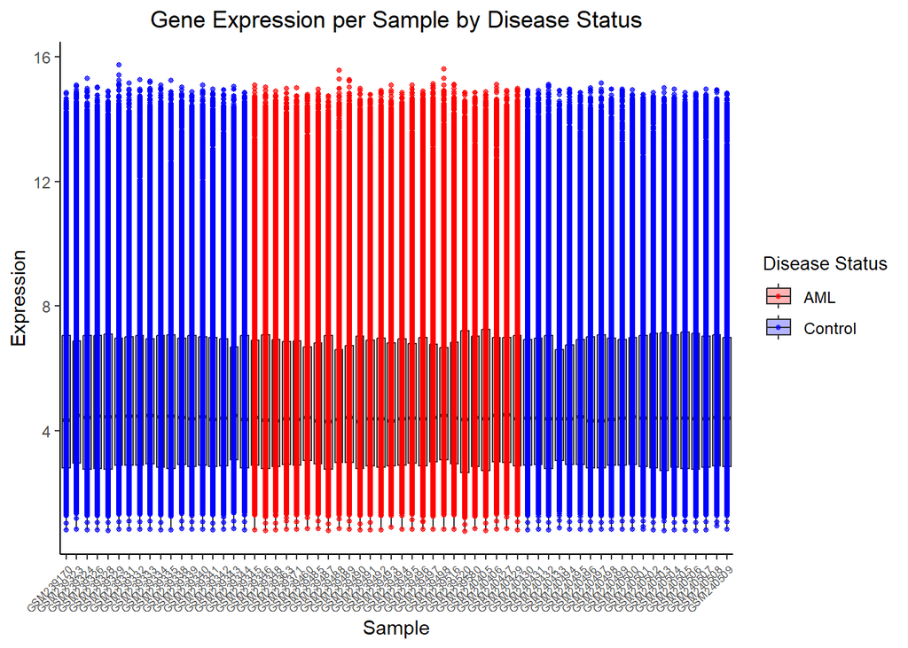

```r
# Load required libraries
library(ggplot2)   # For plotting
library(dplyr)     # For data manipulation
library(tidyr)     # For data reshaping (wide ↔ long)

# Clean the gene expression data
expression_data_clean <- raw_expression_data %>%
  select(where(is.numeric)) %>%                                # Retain only numeric data columns (sample expression values)
  mutate(ID_REF = raw_expression_data$ID_REF)                  # Add back ID_REF for gene tracking

# Reshape the expression data into long format
tidy_Gene_Expression <- expression_data_clean %>%
  pivot_longer(
    cols = -ID_REF,                                            # All columns except ID_REF are sample columns
    names_to = "SampleID",                                     # Rename the sample column headers to 'SampleID'
    values_to = "Expression",                                  # for Storing expression values under 'Expression'
    values_drop_na = TRUE                                      # TO drop any missing values for cleaner output
  )

# Load sample metadata
sample_metadata <- read.table(
  "C:/Users/44798/Downloads/Archive-datasets (1) (1)/GSE9476_meta_info.txt",
  header = TRUE, sep = "\t", fill = TRUE, stringsAsFactors = FALSE
)

#  Merge expression data with metadata
expression_long <- merge(tidy_Gene_Expression, sample_metadata, by = "SampleID")

#  Create the boxplot
ggplot(expression_long, aes(x = SampleID, y = Expression)) +
  # Add boxplots for each sample with semi-transparent fill
  geom_boxplot(aes(fill = Disease_status), outlier.shape = NA, alpha = 0.3) +

  # Add individual data points without jitter
  geom_point(aes(color = Disease_status), size = 1, alpha = 0.7) +

  # Manual color mapping: AML = red, Control = blue
  scale_fill_manual(values = c("AML" = "red", "Control" = "blue")) +
  scale_color_manual(values = c("AML" = "red", "Control" = "blue")) +

  # Clean theme and formatting
  theme_classic() +
  theme(
    axis.text.x = element_text(angle = 45, hjust = 1, size = 6),   # Adjust x-axis labels for better readability and clarity
    legend.title = element_text(size = 10),
    legend.text = element_text(size = 9),
    plot.title = element_text(hjust = 0.5)
  ) +

  # Labels for clarity
  labs(
    title = "Gene Expression per Sample by Disease Status",
    x = "Sample",
    y = "Expression",
    fill = "Disease Status",
    color = "Disease Status"
  )
```

**question 5.5** Create a table to include mean_AML, sd_AML, min_AML, max_AML, mean_Control,sd_Control, min_Control, max_Control, and Fold_change (i.e, mean_AML –mean_Control) for each gene. It is fine to use built-in functions.Hints: split the data set into AML data and normal data sets, and then for each gene/probeset, calculate its mean, standard derivation, min, and max expression values across samples separately (using a built-in function), and further merge these statistical values for each gene into one table. Apply data.frame() and give the created table the same row names as the gene expression data table.

```r
#  Read the gene expression data
raw_expression_data <- read.table( "C:/Users/44798/Downloads/Archive-datasets (1) (1)/GSE9476_series_matrix.txt",header = TRUE, sep = "\t",skip = 83,fill = TRUE, stringsAsFactors = FALSE)

# Extract gene/probe IDs and remove the ID_REF column
gene_ids <- raw_expression_data$ID_REF
expression_data <- raw_expression_data[, -1]

#  Ensure all values are numeric
expression_data <- as.data.frame(lapply(expression_data, function(x) as.numeric(as.character(x))))
rownames(expression_data) <- gene_ids  # Assign gene IDs as row names

# Load the metadata that contains disease status per sample
meta_info <- read.table("C:/Users/44798/Downloads/Archive-datasets (1) (1)/GSE9476_meta_info.txt", header = TRUE, sep = "\t",fill = TRUE,stringsAsFactors = FALSE)

# Match expression data with metadata
common_samples <- intersect(colnames(expression_data), meta_info$SampleID)
expression_data <- expression_data[, common_samples]
meta_info_filtered <- meta_info[meta_info$SampleID %in% common_samples, ]

# Split data by disease status
AML_sample_ids <- meta_info_filtered$SampleID[meta_info_filtered$Disease_status == "AML"]
Control_sample_ids <- meta_info_filtered$SampleID[meta_info_filtered$Disease_status == "Control"]

AML_samples <- expression_data[, AML_sample_ids]
Control_samples <- expression_data[, Control_sample_ids]

# Filter out genes with all NAs in either group
valid_genes <- rowSums(!is.na(AML_samples)) > 0 & rowSums(!is.na(Control_samples)) > 0
AML_samples <- AML_samples[valid_genes, ]
Control_samples <- Control_samples[valid_genes, ]

# Calculate summary statistics
summary_table <- data.frame(
  mean_AML = rowMeans(AML_samples, na.rm = TRUE),
  sd_AML = apply(AML_samples, 1, sd, na.rm = TRUE),
  min_AML = apply(AML_samples, 1, min, na.rm = TRUE),
  max_AML = apply(AML_samples, 1, max, na.rm = TRUE),

  mean_Control = rowMeans(Control_samples, na.rm = TRUE),
  sd_Control = apply(Control_samples, 1, sd, na.rm = TRUE),
  min_Control = apply(Control_samples, 1, min, na.rm = TRUE),
  max_Control = apply(Control_samples, 1, max, na.rm = TRUE),

  Fold_change = rowMeans(AML_samples, na.rm = TRUE) - rowMeans(Control_samples, na.rm = TRUE)
)

# Assign gene/probe IDs as row names for the summary table
rownames(summary_table) <- rownames(AML_samples)

# View top rows of the final summary table
head(summary_table)
```

```
##           mean_AML     sd_AML  min_AML  max_AML mean_Control sd_Control
## 1007_s_at 3.190831 0.28688658 2.738629 4.189943     3.109452 0.13263540
## 1053_at   6.497534 0.43710532 5.707238 7.603169     6.671247 0.54927460
## 117_at    5.352038 1.54329303 3.961892 9.644181     6.475112 2.63384079
## 121_at    7.449728 0.35013512 6.665644 8.221074     7.176393 0.26198848
## 1255_g_at 2.265448 0.07559105 2.068680 2.398069     2.239653 0.07173247
## 1294_at   7.870432 0.63481967 6.757480 9.531410     7.715736 0.52599571
##           min_Control max_Control Fold_change
## 1007_s_at    2.843774    3.448303  0.08137906
## 1053_at      5.932384    8.143075 -0.17371329
## 117_at       3.923634   12.358038 -1.12307397
## 121_at       6.771577    8.019825  0.27333450
## 1255_g_at    2.099221    2.512393  0.02579531
## 1294_at      6.706907    8.929810  0.15469537
```

**question 5.6** With the table created above, make a scatter plot of the mean expression of AMLvs Control samples. Are mean_AML and mean_Control significantly different.

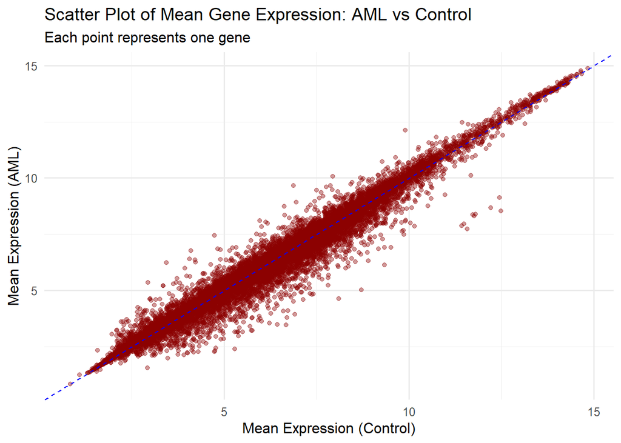

```r
ggplot(summary_table, aes(x = mean_Control, y = mean_AML)) +
  geom_point(alpha = 0.4, color = "darkred") +
  geom_abline(slope = 1, intercept = 0, color = "blue", linetype = "dashed") +
  labs(
    title = "Scatter Plot of Mean Gene Expression: AML vs Control",
    subtitle = "Each point represents one gene",
    x = "Mean Expression (Control)",
    y = "Mean Expression (AML)"
  ) +
  theme_minimal(base_size = 12)
```

```r
t_test_paired <- t.test(summary_table$mean_AML, summary_table$mean_Control, paired = TRUE)
print(t_test_paired)
```

```
##
##  Paired t-test
##
## data:  summary_table$mean_AML and summary_table$mean_Control
## t = -6.8546, df = 22282, p-value = 7.336e-12
## alternative hypothesis: true mean difference is not equal to 0
## 95 percent confidence interval:
##  -0.02303778 -0.01279226
## sample estimates:
## mean difference
##     -0.01791502
```

**QUESTION 5,7** For each gene/probeset, conduct t-test between AML samples and Control samples, and then create a table including t scores and p-values from t-test, and merge to the table created in 6

```r
#  Prepare empty vectors to store t-test statistics
gene_t_scores <- numeric(nrow(AML_samples))   # Vector to store t-scores
gene_p_values <- numeric(nrow(AML_samples))   # Vector to store p-values

# Get gene IDs (same for AML and Control)
gene_ids <- rownames(AML_samples)

# Loop through each gene and perform a two-sample t-test
for (i in 1:nrow(AML_samples)) {

  # Extract expression values for AML and Control samples for gene i
  aml_expression <- as.numeric(AML_samples[i, ])
  control_expression <- as.numeric(Control_samples[i, ])

  # Perform two-sample t-test
  t_test_result <- t.test(aml_expression, control_expression)

  # Store the test statistics
  gene_t_scores[i] <- t_test_result$statistic
  gene_p_values[i] <- t_test_result$p.value
}

#  Add t-test results to the existing summary table
summary_table$t_score <- gene_t_scores
summary_table$p_value <- gene_p_values

# Step 5: Preview results
head(summary_table)
```

```
##           mean_AML     sd_AML  min_AML  max_AML mean_Control sd_Control
## 1007_s_at 3.190831 0.28688658 2.738629 4.189943     3.109452 0.13263540
## 1053_at   6.497534 0.43710532 5.707238 7.603169     6.671247 0.54927460
## 117_at    5.352038 1.54329303 3.961892 9.644181     6.475112 2.63384079
## 121_at    7.449728 0.35013512 6.665644 8.221074     7.176393 0.26198848
## 1255_g_at 2.265448 0.07559105 2.068680 2.398069     2.239653 0.07173247
## 1294_at   7.870432 0.63481967 6.757480 9.531410     7.715736 0.52599571
##           min_Control max_Control Fold_change   t_score     p_value
## 1007_s_at    2.843774    3.448303  0.08137906  1.350983 0.186066483
## 1053_at      5.932384    8.143075 -0.17371329 -1.404938 0.165154359
## 117_at       3.923634   12.358038 -1.12307397 -2.144890 0.035966515
## 121_at       6.771577    8.019825  0.27333450  3.384720 0.001518826
## 1255_g_at    2.099221    2.512393  0.02579531  1.368728 0.176971972
## 1294_at      6.706907    8.929810  0.15469537  1.024930 0.310643245
```

**question 5.8** How many genes/probesets are left after the following filters? a.) mean_AML > 3 and mean_Control > 3 b.) max_AML < 14 or max_Control < 14 c)Apply a) and b) filters together which is more stringent than applying a) or b) alone

```r
# Filter A: Genes with high average expression in both AML and Control (> 3)
genes_passing_filter_a <- summary_table %>%
  filter(mean_AML > 3 & mean_Control > 3)

# Filter B: Genes where max expression in either group is below 14

genes_passing_filter_b <- summary_table %>%
  filter(max_AML < 14 | max_Control < 14)

# Filter C: Apply both filters together — more stringent
genes_passing_filter_c <- genes_passing_filter_a %>%
  filter(max_AML < 14 | max_Control < 14)

# Output the number of genes after each filtering step
cat("Number of genes after Filter A (mean > 3):", nrow(genes_passing_filter_a), "\n")
```

```
## Number of genes after Filter A (mean > 3): 16026
```

```r
cat("Number of genes after Filter B (max < 14):", nrow(genes_passing_filter_b), "\n")
```

```
## Number of genes after Filter B (max < 14): 22171
```

```r
cat("Number of genes after applying both filters (A + B):", nrow(genes_passing_filter_c), "\n")
```

```
## Number of genes after applying both filters (A + B): 15914
```

**QUESTION 5.9** Following 8, if we further filter gene/probeset by applying p-value < 0.05 and the absolute value of log2 Fold_change bigger than 1, then how many genes will be left which we call them significantly expressed genes (DEGs)? Among them, how many are up-regulated (Fold_change > 0) and how many are down-regulated (Fold_change < 0)? List top 10 most upregulated DEGs and 10 most down-regulated DEGs includingtheir p-value, log2FC, and mean values in each sample group

```r
# Filter significantly differentially expressed genes (DEGs)
# Criteria:
# - p-value < 0.05
# - absolute Fold_change > 1
significant_genes <- summary_table %>%
  filter(p_value < 0.05 & abs(Fold_change) > 1)

# Classify DEGs into upregulated and downregulated

# Upregulated: genes with positive Fold_change (higher in AML)
upregulated_genes <- significant_genes %>%
  filter(Fold_change > 0)

# Downregulated: genes with negative Fold_change (lower in AML)
downregulated_genes <- significant_genes %>%
  filter(Fold_change < 0)

# Count DEGs and report summary

cat("Total DEGs:", nrow(significant_genes), "\n")
```

```
## Total DEGs: 709
```

```r
cat("Upregulated genes:", nrow(upregulated_genes), "\n")
```

```
## Upregulated genes: 161
```

```r
cat("Downregulated genes:", nrow(downregulated_genes), "\n")
```

```
## Downregulated genes: 548
```

```r
# Get top 10 most upregulated DEGs (postive)
# Sorted by highest Fold_change
top_10_upregulated <- upregulated_genes %>%
  arrange(desc(Fold_change)) %>%
  select(Fold_change, p_value, mean_AML, mean_Control) %>%
  head(10)

# Add gene names as a column
top_10_upregulated$GeneID <- rownames(top_10_upregulated)
top_10_upregulated <- top_10_upregulated %>%
  select(GeneID, everything())

# Get top 10 most downregulated DEGs
# Sorted by lowest Fold_change (most negative)
top_10_downregulated <- downregulated_genes %>%
  arrange(Fold_change) %>%
  select(Fold_change, p_value, mean_AML, mean_Control) %>%
  head(10)

# Add gene names as a column
top_10_downregulated$GeneID <- rownames(top_10_downregulated)
top_10_downregulated <- top_10_downregulated %>%
  select(GeneID, everything())

# Print the top DEGs to the console

cat("\nTop 10 Most Upregulated Genes:\n")
```

```
##
## Top 10 Most Upregulated Genes:
```

```r
print(top_10_upregulated)
```

```
##                  GeneID Fold_change      p_value  mean_AML mean_Control
## 215489_x_at 215489_x_at    2.806378 3.021987e-08  6.237537     3.431159
## 206674_at     206674_at    2.793421 8.237636e-11  9.669838     6.876417
## 210365_at     210365_at    2.704195 5.128225e-10  7.441080     4.736884
## 204647_at     204647_at    2.667401 8.013568e-07  6.764131     4.096730
## 205899_at     205899_at    2.415503 1.340771e-05  5.350765     2.935262
## 206067_s_at 206067_s_at    2.337609 1.433770e-06  6.391956     4.054346
## 201105_at     201105_at    2.236181 7.396949e-09 12.127482     9.891301
## 205131_x_at 205131_x_at    2.150490 8.268710e-04  6.354558     4.204067
## 214575_s_at 214575_s_at    2.147387 6.393440e-03  8.107346     5.959960
## 205382_s_at 205382_s_at    2.146922 8.140686e-04 10.078486     7.931564
```

```r
cat("\nTop 10 Most Downregulated Genes:\n")
```

```
##
## Top 10 Most Downregulated Genes:
```

```r
print(top_10_downregulated)
```

```
##                  GeneID Fold_change      p_value mean_AML mean_Control
## 209116_x_at 209116_x_at   -3.950883 8.365940e-07 8.538463    12.489345
## 217414_x_at 217414_x_at   -3.837153 2.521879e-05 7.740921    11.578075
## 212224_at     212224_at   -3.699978 3.104044e-10 5.010834     8.710812
## 217232_x_at 217232_x_at   -3.545056 2.163963e-07 8.668270    12.213326
## 209458_x_at 209458_x_at   -3.535036 2.630755e-05 7.884379    11.419415
## 211699_x_at 211699_x_at   -3.516957 2.560269e-05 7.962659    11.479616
## 204018_x_at 204018_x_at   -3.458872 2.807991e-05 8.299976    11.758847
## 206207_at     206207_at   -3.452333 2.389381e-06 4.638640     8.090973
## 211745_x_at 211745_x_at   -3.414876 2.428234e-05 8.387930    11.802806
## 214414_x_at 214414_x_at   -3.356328 5.951027e-05 8.370409    11.726737
```

**QUESTION 5.10** If you apply the limma package rather than t-test, then how many DEGs will be discovered by limma? (p-value < 0.05 & abs(log2FC) > 1). How many overlapped DEGs by these two different approaches? please draw a Venn diagram for demonstration.

```r
# Load Required Libraries
library(limma)         # Linear models for microarray data
library(VennDiagram)   # For creating Venn diagrams
library(grid)          # For drawing graphics
library(dplyr)         # Data manipulation

# Ensure disease status is a factor
meta_info_filtered$Disease_status <- factor(meta_info_filtered$Disease_status)

# Create design matrix for limma
design <- model.matrix(~ 0 + meta_info_filtered$Disease_status)
colnames(design) <- levels(meta_info_filtered$Disease_status)  # Rename columns to "AML" and "Control"

# Fit linear model
fit <- lmFit(expression_data, design)

#  Define contrast (AML vs Control) and apply eBayes moderation
contrast.matrix <- makeContrasts(AML - Control, levels = design)
fit2 <- contrasts.fit(fit, contrast.matrix)
fit2 <- eBayes(fit2)

# Extract limma results table
limma_table <- topTable(fit2, coef = 1, adjust.method = "BH", sort.by = "P", number = Inf)

# Filter significant DEGs from limma
limma_DEGs <- limma_table %>%
  filter(P.Value < 0.05 & abs(logFC) > 1)

limma_DEG_IDs <- rownames(limma_DEGs)  # Save gene/probe IDs

# Extract t-test DEGs from previous summary_table

# Ensure gene IDs are available in a column
if (!"ID_REF" %in% colnames(summary_table)) {
  summary_table <- summary_table %>%
    tibble::rownames_to_column(var = "ID_REF")
}

# Filter DEGs from t-test approach
significant_genes <- summary_table %>%
  filter(p_value < 0.05 & abs(Fold_change) > 1)

t_test_DEGs <- significant_genes$ID_REF  # Save gene/probe IDs

# Find overlapping DEGs between limma and t-test
overlapping_genes <- intersect(t_test_DEGs, limma_DEG_IDs)

#  Result of DEG statistics
cat("Number of DEGs from t-test:", length(t_test_DEGs), "\n")
```

```
## Number of DEGs from t-test: 709
```

```r
cat("Number of DEGs from limma:", length(limma_DEG_IDs), "\n")
```

```
## Number of DEGs from limma: 708
```

```r
cat("Number of overlapping DEGs:", length(overlapping_genes), "\n")
```

```
## Number of overlapping DEGs: 702
```

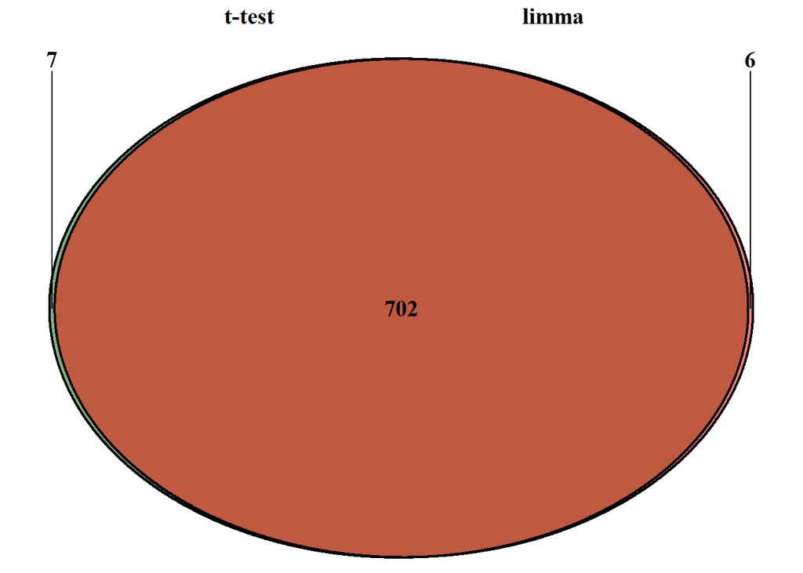

```r
# Create a Venn diagram to visualise overlap
venn_list <- list(
  `t-test` = t_test_DEGs,
  `limma` = limma_DEG_IDs
)

venn.plot <- venn.diagram(
  x = venn_list,
  category.names = c("t-test", "limma"),
  filename = NULL,                # Keep output in R (no file export)
  output = TRUE,                  # Return graphical object
  lwd = 2,
  fill = c("darkgreen", "red"),
  alpha = 0.5,
  cex = 1.2,
  fontface = "bold",
  cat.cex = 1.2,
  cat.fontface = "bold",
  cat.pos = c(-20, 20),
  cat.dist = 0.05
)

# Plot the Venn diagram
grid.newpage()
grid.draw(venn.plot)
```